# Risk Factor Analysis

## Outcome Variable

**Outcome Variable:** ever_stunted

## Predictor Variables

**Intervention Variable:** tr

**Adjustment Set:**

unadjusted

## Stratifying Variables

The analysis was stratified on these variable(s):

- predexfd6
- agecat
- studyid
- country

## Data Summary

| predexfd6 | agecat | studyid | country | tr | ever_stunted | n_cell | n |
| --- | --- | --- | --- | --- | --- | --- | --- |
| 1 | 0-6 months | ki1000304b-SAS-CompFeed | INDIA | Control | 0 | 51 | 206 |
| 1 | 0-6 months | ki1000304b-SAS-CompFeed | INDIA | Control | 1 | 25 | 206 |
| 1 | 0-6 months | ki1000304b-SAS-CompFeed | INDIA | Other | 0 | 89 | 206 |
| 1 | 0-6 months | ki1000304b-SAS-CompFeed | INDIA | Other | 1 | 41 | 206 |
| 0 | 0-6 months | ki1000304b-SAS-CompFeed | INDIA | Control | 0 | 6 | 12 |
| 0 | 0-6 months | ki1000304b-SAS-CompFeed | INDIA | Control | 1 | 3 | 12 |
| 0 | 0-6 months | ki1000304b-SAS-CompFeed | INDIA | Other | 0 | 3 | 12 |
| 0 | 0-6 months | ki1000304b-SAS-CompFeed | INDIA | Other | 1 | 0 | 12 |
| 0 | 0-6 months | ki1000304b-SAS-FoodSuppl | INDIA | Control | 0 | 25 | 183 |
| 0 | 0-6 months | ki1000304b-SAS-FoodSuppl | INDIA | Control | 1 | 22 | 183 |
| 0 | 0-6 months | ki1000304b-SAS-FoodSuppl | INDIA | Other | 0 | 70 | 183 |
| 0 | 0-6 months | ki1000304b-SAS-FoodSuppl | INDIA | Other | 1 | 66 | 183 |
| 0 | 0-6 months | ki1017093b-PROVIDE | BANGLADESH | Control | 0 | 104 | 473 |
| 0 | 0-6 months | ki1017093b-PROVIDE | BANGLADESH | Control | 1 | 20 | 473 |
| 0 | 0-6 months | ki1017093b-PROVIDE | BANGLADESH | Other | 0 | 300 | 473 |
| 0 | 0-6 months | ki1017093b-PROVIDE | BANGLADESH | Other | 1 | 49 | 473 |
| 1 | 0-6 months | ki1017093b-PROVIDE | BANGLADESH | Control | 0 | 38 | 167 |
| 1 | 0-6 months | ki1017093b-PROVIDE | BANGLADESH | Control | 1 | 4 | 167 |
| 1 | 0-6 months | ki1017093b-PROVIDE | BANGLADESH | Other | 0 | 109 | 167 |
| 1 | 0-6 months | ki1017093b-PROVIDE | BANGLADESH | Other | 1 | 16 | 167 |
| 1 | 0-6 months | ki1148112-iLiNS-DOSE | MALAWI | Control | 0 | 113 | 1014 |
| 1 | 0-6 months | ki1148112-iLiNS-DOSE | MALAWI | Control | 1 | 52 | 1014 |
| 1 | 0-6 months | ki1148112-iLiNS-DOSE | MALAWI | LNS | 0 | 614 | 1014 |
| 1 | 0-6 months | ki1148112-iLiNS-DOSE | MALAWI | LNS | 1 | 235 | 1014 |
| 0 | 0-6 months | ki1148112-iLiNS-DOSE | MALAWI | Control | 0 | 14 | 161 |
| 0 | 0-6 months | ki1148112-iLiNS-DOSE | MALAWI | Control | 1 | 6 | 161 |
| 0 | 0-6 months | ki1148112-iLiNS-DOSE | MALAWI | LNS | 0 | 96 | 161 |
| 0 | 0-6 months | ki1148112-iLiNS-DOSE | MALAWI | LNS | 1 | 45 | 161 |
| 1 | 0-6 months | ki1148112-iLiNS-DYAD-M | MALAWI | Maternal | 0 | 2 | 2 |
| 0 | 0-6 months | ki1148112-iLiNS-DYAD-M | MALAWI | Control | 1 | 1 | 2 |

[output cut: 187 more lines]

The following strata were considered:

- predexfd6: 0, agecat: 0-24 months, studyid: iLiNS_DYADM_LNS, country: MALAWI
- predexfd6: 0, agecat: 0-24 months, studyid: ki1000304b-SAS-CompFeed, country: INDIA
- predexfd6: 0, agecat: 0-24 months, studyid: ki1000304b-SAS-FoodSuppl, country: INDIA
- predexfd6: 0, agecat: 0-24 months, studyid: ki1017093b-PROVIDE, country: BANGLADESH
- predexfd6: 0, agecat: 0-24 months, studyid: ki1148112-iLiNS-DOSE, country: MALAWI
- predexfd6: 0, agecat: 0-24 months, studyid: ki1148112-iLiNS-DYAD-M, country: MALAWI
- predexfd6: 0, agecat: 0-24 months, studyid: ki1148112-LCNI-5, country: MALAWI
- predexfd6: 0, agecat: 0-24 months, studyid: kiGH5241-JiVitA-3, country: BANGLADESH
- predexfd6: 0, agecat: 0-24 months, studyid: kiGH5241-JiVitA-4, country: BANGLADESH
- predexfd6: 0, agecat: 0-6 months, studyid: iLiNS_DYADM_LNS, country: MALAWI
- predexfd6: 0, agecat: 0-6 months, studyid: ki1000304b-SAS-CompFeed, country: INDIA
- predexfd6: 0, agecat: 0-6 months, studyid: ki1000304b-SAS-FoodSuppl, country: INDIA
- predexfd6: 0, agecat: 0-6 months, studyid: ki1017093b-PROVIDE, country: BANGLADESH
- predexfd6: 0, agecat: 0-6 months, studyid: ki1148112-iLiNS-DOSE, country: MALAWI
- predexfd6: 0, agecat: 0-6 months, studyid: ki1148112-iLiNS-DYAD-M, country: MALAWI
- predexfd6: 0, agecat: 0-6 months, studyid: ki1148112-LCNI-5, country: MALAWI
- predexfd6: 0, agecat: 0-6 months, studyid: kiGH5241-JiVitA-3, country: BANGLADESH
- predexfd6: 0, agecat: 0-6 months, studyid: kiGH5241-JiVitA-4, country: BANGLADESH
- predexfd6: 0, agecat: 6-24 months, studyid: iLiNS_DYADM_LNS, country: MALAWI
- predexfd6: 0, agecat: 6-24 months, studyid: ki1000304b-SAS-CompFeed, country: INDIA
- predexfd6: 0, agecat: 6-24 months, studyid: ki1000304b-SAS-FoodSuppl, country: INDIA
- predexfd6: 0, agecat: 6-24 months, studyid: ki1017093b-PROVIDE, country: BANGLADESH
- predexfd6: 0, agecat: 6-24 months, studyid: ki1148112-iLiNS-DOSE, country: MALAWI
- predexfd6: 0, agecat: 6-24 months, studyid: ki1148112-iLiNS-DYAD-M, country: MALAWI
- predexfd6: 0, agecat: 6-24 months, studyid: ki1148112-LCNI-5, country: MALAWI
- predexfd6: 0, agecat: 6-24 months, studyid: kiGH5241-JiVitA-3, country: BANGLADESH
- predexfd6: 0, agecat: 6-24 months, studyid: kiGH5241-JiVitA-4, country: BANGLADESH
- predexfd6: 1, agecat: 0-24 months, studyid: iLiNS_DYADM_LNS, country: MALAWI
- predexfd6: 1, agecat: 0-24 months, studyid: ki1000304b-SAS-CompFeed, country: INDIA
- predexfd6: 1, agecat: 0-24 months, studyid: ki1017093b-PROVIDE, country: BANGLADESH
- predexfd6: 1, agecat: 0-24 months, studyid: ki1148112-iLiNS-DOSE, country: MALAWI
- predexfd6: 1, agecat: 0-24 months, studyid: ki1148112-iLiNS-DYAD-M, country: MALAWI
- predexfd6: 1, agecat: 0-24 months, studyid: ki1148112-LCNI-5, country: MALAWI
- predexfd6: 1, agecat: 0-24 months, studyid: kiGH5241-JiVitA-3, country: BANGLADESH
- predexfd6: 1, agecat: 0-24 months, studyid: kiGH5241-JiVitA-4, country: BANGLADESH
- predexfd6: 1, agecat: 0-6 months, studyid: iLiNS_DYADM_LNS, country: MALAWI
- predexfd6: 1, agecat: 0-6 months, studyid: ki1000304b-SAS-CompFeed, country: INDIA
- predexfd6: 1, agecat: 0-6 months, studyid: ki1017093b-PROVIDE, country: BANGLADESH
- predexfd6: 1, agecat: 0-6 months, studyid: ki1148112-iLiNS-DOSE, country: MALAWI
- predexfd6: 1, agecat: 0-6 months, studyid: ki1148112-iLiNS-DYAD-M, country: MALAWI
- predexfd6: 1, agecat: 0-6 months, studyid: ki1148112-LCNI-5, country: MALAWI
- predexfd6: 1, agecat: 0-6 months, studyid: kiGH5241-JiVitA-3, country: BANGLADESH
- predexfd6: 1, agecat: 0-6 months, studyid: kiGH5241-JiVitA-4, country: BANGLADESH
- predexfd6: 1, agecat: 6-24 months, studyid: iLiNS_DYADM_LNS, country: MALAWI
- predexfd6: 1, agecat: 6-24 months, studyid: ki1000304b-SAS-CompFeed, country: INDIA
- predexfd6: 1, agecat: 6-24 months, studyid: ki1017093b-PROVIDE, country: BANGLADESH
- predexfd6: 1, agecat: 6-24 months, studyid: ki1148112-iLiNS-DOSE, country: MALAWI
- predexfd6: 1, agecat: 6-24 months, studyid: ki1148112-iLiNS-DYAD-M, country: MALAWI
- predexfd6: 1, agecat: 6-24 months, studyid: ki1148112-LCNI-5, country: MALAWI
- predexfd6: 1, agecat: 6-24 months, studyid: kiGH5241-JiVitA-3, country: BANGLADESH
- predexfd6: 1, agecat: 6-24 months, studyid: kiGH5241-JiVitA-4, country: BANGLADESH

### Dropped Strata

Some strata were dropped due to rare outcomes:

- predexfd6: 0, agecat: 0-6 months, studyid: ki1000304b-SAS-CompFeed, country: INDIA
- predexfd6: 1, agecat: 0-6 months, studyid: ki1017093b-PROVIDE, country: BANGLADESH
- predexfd6: 1, agecat: 0-6 months, studyid: ki1148112-iLiNS-DYAD-M, country: MALAWI
- predexfd6: 0, agecat: 0-6 months, studyid: ki1148112-iLiNS-DYAD-M, country: MALAWI
- predexfd6: 1, agecat: 0-6 months, studyid: ki1148112-LCNI-5, country: MALAWI
- predexfd6: 0, agecat: 6-24 months, studyid: ki1000304b-SAS-CompFeed, country: INDIA
- predexfd6: 0, agecat: 6-24 months, studyid: ki1148112-iLiNS-DOSE, country: MALAWI
- predexfd6: 1, agecat: 6-24 months, studyid: ki1148112-iLiNS-DYAD-M, country: MALAWI
- predexfd6: 0, agecat: 6-24 months, studyid: ki1148112-iLiNS-DYAD-M, country: MALAWI
- predexfd6: 1, agecat: 6-24 months, studyid: ki1148112-LCNI-5, country: MALAWI
- predexfd6: 0, agecat: 0-24 months, studyid: ki1000304b-SAS-CompFeed, country: INDIA
- predexfd6: 0, agecat: 0-24 months, studyid: ki1148112-iLiNS-DYAD-M, country: MALAWI
- predexfd6: 1, agecat: 0-24 months, studyid: ki1148112-LCNI-5, country: MALAWI
- predexfd6: 0, agecat: 0-6 months, studyid: iLiNS_DYADM_LNS, country: MALAWI
- predexfd6: 1, agecat: 0-6 months, studyid: iLiNS_DYADM_LNS, country: MALAWI
- predexfd6: 1, agecat: 6-24 months, studyid: iLiNS_DYADM_LNS, country: MALAWI
- predexfd6: 0, agecat: 6-24 months, studyid: iLiNS_DYADM_LNS, country: MALAWI
- predexfd6: 0, agecat: 0-24 months, studyid: iLiNS_DYADM_LNS, country: MALAWI

## Methods Detail

We’re interested in the causal parameters $E[Y_a]$ for all values of $a \in \mathcal{A}$. These parameters represent the mean outcome if, possibly contrary to fact, we intervened to set all units to have $A=a$. Under the randomization and positivity assumptions, these are identified by the statistical parameters $\psi_a=E_W[E_{Y|A,W}(Y|A=a,W)]$. In addition, we’re interested in the mean of $Y$, $E[Y]$ under no intervention (the observed mean). We will estimate these parameters by using SuperLearner to fit the relevant likelihood factors – $E_{Y|A,W}(Y|A=a,W)$ and $p(A=a|W)$, and then updating our likelihood fit using a joint TMLE.

For unadjusted analyses ($W=\{\}$), initial likelihoods were estimated using Lrnr_glm to estimate the simple $E(Y|A)$ and Lrnr_mean to estimate $p(A)$. For adjusted analyses, a small library containing Lrnr_glmnet, Lrnr_xgboost, and Lrnr_mean was used.

Having estimated these parameters, we will then use the delta method to estimate relative risks and attributable risks relative to a prespecified baseline level of $A$.

# Results Detail

## Results Plots

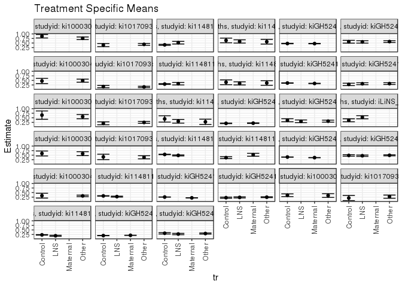

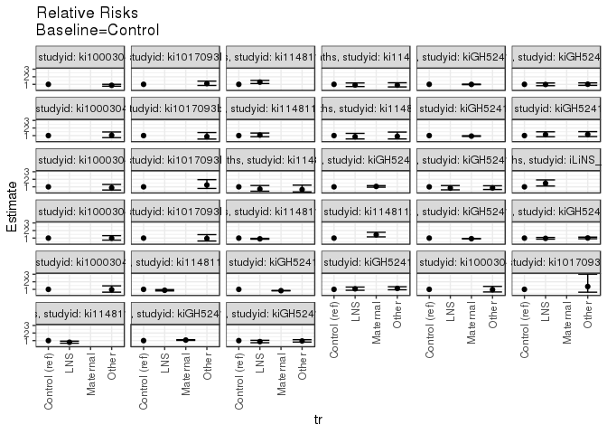

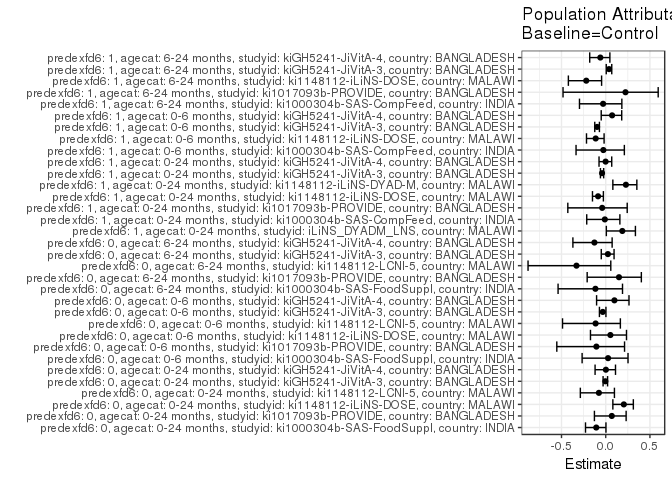

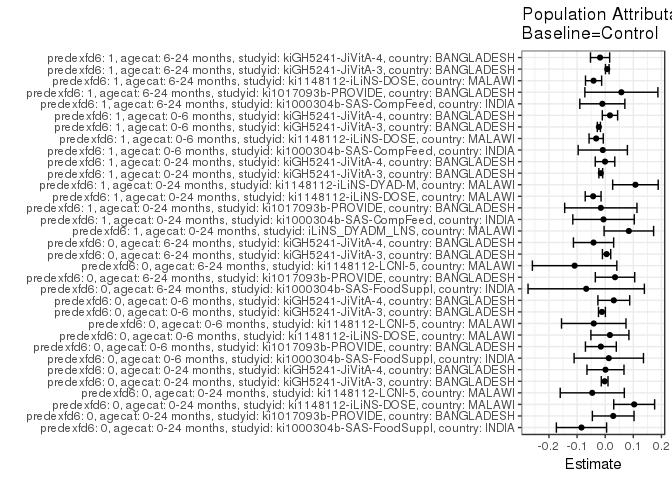

## Results Table

### Parameter: TSM

| predexfd6 | agecat | studyid | country | intervention_level | baseline_level | estimate | ci_lower | ci_upper |
| --- | --- | --- | --- | --- | --- | --- | --- | --- |
| 0 | 0-24 months | ki1000304b-SAS-FoodSuppl | INDIA | Control | NA | 0.8723404 | 0.7766756 | 0.9680052 |
| 0 | 0-24 months | ki1000304b-SAS-FoodSuppl | INDIA | Other | NA | 0.7591241 | 0.6873241 | 0.8309241 |
| 0 | 0-24 months | ki1017093b-PROVIDE | BANGLADESH | Control | NA | 0.3870968 | 0.3012742 | 0.4729194 |
| 0 | 0-24 months | ki1017093b-PROVIDE | BANGLADESH | Other | NA | 0.4257143 | 0.3738587 | 0.4775699 |
| 0 | 0-24 months | ki1148112-iLiNS-DOSE | MALAWI | Control | NA | 0.4000000 | 0.3732456 | 0.4267544 |
| 0 | 0-24 months | ki1148112-iLiNS-DOSE | MALAWI | LNS | NA | 0.5177305 | 0.4452733 | 0.5901877 |
| 0 | 0-24 months | ki1148112-LCNI-5 | MALAWI | Control | NA | 0.6415094 | 0.5121143 | 0.7709045 |
| 0 | 0-24 months | ki1148112-LCNI-5 | MALAWI | LNS | NA | 0.5862069 | 0.4963806 | 0.6760332 |
| 0 | 0-24 months | ki1148112-LCNI-5 | MALAWI | Other | NA | 0.5714286 | 0.4415271 | 0.7013300 |
| 0 | 0-24 months | kiGH5241-JiVitA-3 | BANGLADESH | Control | NA | 0.4717949 | 0.4598266 | 0.4837632 |
| 0 | 0-24 months | kiGH5241-JiVitA-3 | BANGLADESH | Maternal | NA | 0.4678511 | 0.4559366 | 0.4797656 |
| 0 | 0-24 months | kiGH5241-JiVitA-4 | BANGLADESH | Control | NA | 0.5702479 | 0.4938952 | 0.6466006 |
| 0 | 0-24 months | kiGH5241-JiVitA-4 | BANGLADESH | LNS | NA | 0.5602837 | 0.4939817 | 0.6265857 |
| 0 | 0-24 months | kiGH5241-JiVitA-4 | BANGLADESH | Other | NA | 0.5780933 | 0.5272007 | 0.6289859 |
| 0 | 0-6 months | ki1000304b-SAS-FoodSuppl | INDIA | Control | NA | 0.4680851 | 0.3250402 | 0.6111300 |
| 0 | 0-6 months | ki1000304b-SAS-FoodSuppl | INDIA | Other | NA | 0.4852941 | 0.4010673 | 0.5695210 |
| 0 | 0-6 months | ki1017093b-PROVIDE | BANGLADESH | Control | NA | 0.1612903 | 0.0964856 | 0.2260951 |
| 0 | 0-6 months | ki1017093b-PROVIDE | BANGLADESH | Other | NA | 0.1404011 | 0.1039150 | 0.1768873 |
| 0 | 0-6 months | ki1148112-iLiNS-DOSE | MALAWI | Control | NA | 0.3000000 | 0.2749735 | 0.3250265 |
| 0 | 0-6 months | ki1148112-iLiNS-DOSE | MALAWI | LNS | NA | 0.3191489 | 0.2515550 | 0.3867428 |
| 0 | 0-6 months | ki1148112-LCNI-5 | MALAWI | Control | NA | 0.3962264 | 0.2642531 | 0.5281997 |
| 0 | 0-6 months | ki1148112-LCNI-5 | MALAWI | LNS | NA | 0.3362069 | 0.2500468 | 0.4223670 |
| 0 | 0-6 months | ki1148112-LCNI-5 | MALAWI | Other | NA | 0.3571429 | 0.2313663 | 0.4829194 |
| 0 | 0-6 months | kiGH5241-JiVitA-3 | BANGLADESH | Control | NA | 0.3555356 | 0.3436548 | 0.3674163 |
| 0 | 0-6 months | kiGH5241-JiVitA-3 | BANGLADESH | Maternal | NA | 0.3313812 | 0.3191732 | 0.3435891 |
| 0 | 0-6 months | kiGH5241-JiVitA-4 | BANGLADESH | Control | NA | 0.2803347 | 0.2157017 | 0.3449677 |
| 0 | 0-6 months | kiGH5241-JiVitA-4 | BANGLADESH | LNS | NA | 0.3165468 | 0.2639459 | 0.3691476 |
| 0 | 0-6 months | kiGH5241-JiVitA-4 | BANGLADESH | Other | NA | 0.3229167 | 0.2734921 | 0.3723412 |
| 0 | 6-24 months | ki1000304b-SAS-FoodSuppl | INDIA | Control | NA | 0.6470588 | 0.4185892 | 0.8755284 |
| 0 | 6-24 months | ki1000304b-SAS-FoodSuppl | INDIA | Other | NA | 0.5633803 | 0.4473549 | 0.6794057 |
| 0 | 6-24 months | ki1017093b-PROVIDE | BANGLADESH | Control | NA | 0.1979167 | 0.1181063 | 0.2777270 |
| 0 | 6-24 months | ki1017093b-PROVIDE | BANGLADESH | Other | NA | 0.2453532 | 0.1938617 | 0.2968446 |
| 0 | 6-24 months | ki1148112-LCNI-5 | MALAWI | Control | NA | 0.4375000 | 0.2650291 | 0.6099709 |
| 0 | 6-24 months | ki1148112-LCNI-5 | MALAWI | LNS | NA | 0.3076923 | 0.2049141 | 0.4104705 |
| 0 | 6-24 months | ki1148112-LCNI-5 | MALAWI | Other | NA | 0.2777778 | 0.1309618 | 0.4245938 |
| 0 | 6-24 months | kiGH5241-JiVitA-3 | BANGLADESH | Control | NA | 0.1942724 | 0.1816836 | 0.2068613 |
| 0 | 6-24 months | kiGH5241-JiVitA-3 | BANGLADESH | Maternal | NA | 0.2044888 | 0.1897432 | 0.2192344 |
| 0 | 6-24 months | kiGH5241-JiVitA-4 | BANGLADESH | Control | NA | 0.3657143 | 0.2828995 | 0.4485291 |
| 0 | 6-24 months | kiGH5241-JiVitA-4 | BANGLADESH | LNS | NA | 0.3062201 | 0.2322213 | 0.3802189 |
| 0 | 6-24 months | kiGH5241-JiVitA-4 | BANGLADESH | Other | NA | 0.3144476 | 0.2599063 | 0.3689889 |
| 1 | 0-24 months | iLiNS_DYADM_LNS | MALAWI | Control | NA | 0.3636364 | 0.2821881 | 0.4450847 |
| 1 | 0-24 months | iLiNS_DYADM_LNS | MALAWI | LNS | NA | 0.5294118 | 0.4436299 | 0.6151936 |
| 1 | 0-24 months | ki1000304b-SAS-CompFeed | INDIA | Control | NA | 0.5922330 | 0.4561328 | 0.7283332 |
| 1 | 0-24 months | ki1000304b-SAS-CompFeed | INDIA | Other | NA | 0.5828571 | 0.4747850 | 0.6909293 |
| 1 | 0-24 months | ki1017093b-PROVIDE | BANGLADESH | Control | NA | 0.4047619 | 0.2558694 | 0.5536544 |
| 1 | 0-24 months | ki1017093b-PROVIDE | BANGLADESH | Other | NA | 0.3840000 | 0.2984828 | 0.4695172 |
| 1 | 0-24 months | ki1148112-iLiNS-DOSE | MALAWI | Control | NA | 0.5393939 | 0.5270243 | 0.5517635 |
| 1 | 0-24 months | ki1148112-iLiNS-DOSE | MALAWI | LNS | NA | 0.4882353 | 0.4600803 | 0.5163903 |
| 1 | 0-24 months | ki1148112-iLiNS-DYAD-M | MALAWI | Control | NA | 0.3636364 | 0.3113057 | 0.4159670 |
| 1 | 0-24 months | ki1148112-iLiNS-DYAD-M | MALAWI | Maternal | NA | 0.5211268 | 0.4414147 | 0.6008388 |
| 1 | 0-24 months | kiGH5241-JiVitA-3 | BANGLADESH | Control | NA | 0.3962005 | 0.3896548 | 0.4027462 |
| 1 | 0-24 months | kiGH5241-JiVitA-3 | BANGLADESH | Maternal | NA | 0.3654267 | 0.3589254 | 0.3719280 |
| 1 | 0-24 months | kiGH5241-JiVitA-4 | BANGLADESH | Control | NA | 0.4850976 | 0.4439182 | 0.5262771 |
| 1 | 0-24 months | kiGH5241-JiVitA-4 | BANGLADESH | LNS | NA | 0.4689042 | 0.4320198 | 0.5057887 |
| 1 | 0-24 months | kiGH5241-JiVitA-4 | BANGLADESH | Other | NA | 0.4933101 | 0.4642918 | 0.5223284 |
| 1 | 0-6 months | ki1000304b-SAS-CompFeed | INDIA | Control | NA | 0.3289474 | 0.1971432 | 0.4607516 |
| 1 | 0-6 months | ki1000304b-SAS-CompFeed | INDIA | Other | NA | 0.3153846 | 0.2742375 | 0.3565318 |
| 1 | 0-6 months | ki1148112-iLiNS-DOSE | MALAWI | Control | NA | 0.3151515 | 0.3036111 | 0.3266920 |
| 1 | 0-6 months | ki1148112-iLiNS-DOSE | MALAWI | LNS | NA | 0.2767962 | 0.2515853 | 0.3020071 |
| 1 | 0-6 months | kiGH5241-JiVitA-3 | BANGLADESH | Control | NA | 0.2532538 | 0.2472871 | 0.2592204 |
| 1 | 0-6 months | kiGH5241-JiVitA-3 | BANGLADESH | Maternal | NA | 0.2093174 | 0.2041234 | 0.2145114 |
| 1 | 0-6 months | kiGH5241-JiVitA-4 | BANGLADESH | Control | NA | 0.2181818 | 0.1867738 | 0.2495899 |
| 1 | 0-6 months | kiGH5241-JiVitA-4 | BANGLADESH | LNS | NA | 0.2334711 | 0.2024696 | 0.2644725 |
| 1 | 0-6 months | kiGH5241-JiVitA-4 | BANGLADESH | Other | NA | 0.2457627 | 0.2209033 | 0.2706221 |
| 1 | 6-24 months | ki1000304b-SAS-CompFeed | INDIA | Control | NA | 0.3521127 | 0.2768199 | 0.4274054 |
| 1 | 6-24 months | ki1000304b-SAS-CompFeed | INDIA | Other | NA | 0.3360656 | 0.2334804 | 0.4386507 |
| 1 | 6-24 months | ki1017093b-PROVIDE | BANGLADESH | Control | NA | 0.2000000 | 0.0563192 | 0.3436808 |
| 1 | 6-24 months | ki1017093b-PROVIDE | BANGLADESH | Other | NA | 0.2745098 | 0.1875749 | 0.3614447 |
| 1 | 6-24 months | ki1148112-iLiNS-DOSE | MALAWI | Control | NA | 0.2291667 | 0.2151175 | 0.2432158 |
| 1 | 6-24 months | ki1148112-iLiNS-DOSE | MALAWI | LNS | NA | 0.1795407 | 0.1508834 | 0.2081981 |
| 1 | 6-24 months | kiGH5241-JiVitA-3 | BANGLADESH | Control | NA | 0.1898391 | 0.1839392 | 0.1957389 |
| 1 | 6-24 months | kiGH5241-JiVitA-3 | BANGLADESH | Maternal | NA | 0.2041441 | 0.1977603 | 0.2105280 |
| 1 | 6-24 months | kiGH5241-JiVitA-4 | BANGLADESH | Control | NA | 0.3175592 | 0.2771759 | 0.3579424 |
| 1 | 6-24 months | kiGH5241-JiVitA-4 | BANGLADESH | LNS | NA | 0.2754854 | 0.2384935 | 0.3124774 |
| 1 | 6-24 months | kiGH5241-JiVitA-4 | BANGLADESH | Other | NA | 0.3029862 | 0.2733678 | 0.3326045 |

### Parameter: E(Y)

| predexfd6 | agecat | studyid | country | intervention_level | baseline_level | estimate | ci_lower | ci_upper |
| --- | --- | --- | --- | --- | --- | --- | --- | --- |
| 0 | 0-24 months | ki1000304b-SAS-FoodSuppl | INDIA | NA | NA | 0.7880435 | 0.7288299 | 0.8472570 |
| 0 | 0-24 months | ki1017093b-PROVIDE | BANGLADESH | NA | NA | 0.4156118 | 0.3711986 | 0.4600250 |
| 0 | 0-24 months | ki1148112-iLiNS-DOSE | MALAWI | NA | NA | 0.5031056 | 0.4256327 | 0.5805785 |
| 0 | 0-24 months | ki1148112-LCNI-5 | MALAWI | NA | NA | 0.5955556 | 0.5312846 | 0.6598265 |
| 0 | 0-24 months | kiGH5241-JiVitA-3 | BANGLADESH | NA | NA | 0.4698918 | 0.4530048 | 0.4867788 |
| 0 | 0-24 months | kiGH5241-JiVitA-4 | BANGLADESH | NA | NA | 0.5712881 | 0.5355266 | 0.6070496 |
| 0 | 0-6 months | ki1000304b-SAS-FoodSuppl | INDIA | NA | NA | 0.4808743 | 0.4082864 | 0.5534623 |
| 0 | 0-6 months | ki1017093b-PROVIDE | BANGLADESH | NA | NA | 0.1458774 | 0.1140331 | 0.1777216 |
| 0 | 0-6 months | ki1148112-iLiNS-DOSE | MALAWI | NA | NA | 0.3167702 | 0.2446854 | 0.3888550 |
| 0 | 0-6 months | ki1148112-LCNI-5 | MALAWI | NA | NA | 0.3555556 | 0.2928696 | 0.4182416 |
| 0 | 0-6 months | kiGH5241-JiVitA-3 | BANGLADESH | NA | NA | 0.3439476 | 0.3268991 | 0.3609960 |
| 0 | 0-6 months | kiGH5241-JiVitA-4 | BANGLADESH | NA | NA | 0.3109328 | 0.2789227 | 0.3429429 |
| 0 | 6-24 months | ki1000304b-SAS-FoodSuppl | INDIA | NA | NA | 0.5795455 | 0.4758185 | 0.6832724 |
| 0 | 6-24 months | ki1017093b-PROVIDE | BANGLADESH | NA | NA | 0.2328767 | 0.1894564 | 0.2762970 |
| 0 | 6-24 months | ki1148112-LCNI-5 | MALAWI | NA | NA | 0.3287671 | 0.2523053 | 0.4052290 |
| 0 | 6-24 months | kiGH5241-JiVitA-3 | BANGLADESH | NA | NA | 0.1991984 | 0.1798000 | 0.2185968 |
| 0 | 6-24 months | kiGH5241-JiVitA-4 | BANGLADESH | NA | NA | 0.3242877 | 0.2853874 | 0.3631879 |
| 1 | 0-24 months | iLiNS_DYADM_LNS | MALAWI | NA | NA | 0.4477612 | 0.3277939 | 0.5677285 |
| 1 | 0-24 months | ki1000304b-SAS-CompFeed | INDIA | NA | NA | 0.5863309 | 0.5013781 | 0.6712838 |
| 1 | 0-24 months | ki1017093b-PROVIDE | BANGLADESH | NA | NA | 0.3892216 | 0.3150505 | 0.4633926 |
| 1 | 0-24 months | ki1148112-iLiNS-DOSE | MALAWI | NA | NA | 0.4965517 | 0.4657774 | 0.5273261 |
| 1 | 0-24 months | ki1148112-iLiNS-DYAD-M | MALAWI | NA | NA | 0.4711538 | 0.3747542 | 0.5675535 |
| 1 | 0-24 months | kiGH5241-JiVitA-3 | BANGLADESH | NA | NA | 0.3804676 | 0.3711540 | 0.3897812 |
| 1 | 0-24 months | kiGH5241-JiVitA-4 | BANGLADESH | NA | NA | 0.4844804 | 0.4644842 | 0.5044767 |
| 1 | 0-6 months | ki1000304b-SAS-CompFeed | INDIA | NA | NA | 0.3203883 | 0.2652569 | 0.3755198 |
| 1 | 0-6 months | ki1148112-iLiNS-DOSE | MALAWI | NA | NA | 0.2830375 | 0.2552970 | 0.3107779 |
| 1 | 0-6 months | kiGH5241-JiVitA-3 | BANGLADESH | NA | NA | 0.2308049 | 0.2227254 | 0.2388845 |
| 1 | 0-6 months | kiGH5241-JiVitA-4 | BANGLADESH | NA | NA | 0.2351617 | 0.2185966 | 0.2517269 |
| 1 | 6-24 months | ki1000304b-SAS-CompFeed | INDIA | NA | NA | 0.3419689 | 0.2712475 | 0.4126904 |
| 1 | 6-24 months | ki1017093b-PROVIDE | BANGLADESH | NA | NA | 0.2575758 | 0.1826914 | 0.3324601 |
| 1 | 6-24 months | ki1148112-iLiNS-DOSE | MALAWI | NA | NA | 0.1878261 | 0.1558743 | 0.2197778 |
| 1 | 6-24 months | kiGH5241-JiVitA-3 | BANGLADESH | NA | NA | 0.1972541 | 0.1885655 | 0.2059428 |
| 1 | 6-24 months | kiGH5241-JiVitA-4 | BANGLADESH | NA | NA | 0.2993333 | 0.2792264 | 0.3194403 |

### Parameter: RR

| predexfd6 | agecat | studyid | country | intervention_level | baseline_level | estimate | ci_lower | ci_upper |
| --- | --- | --- | --- | --- | --- | --- | --- | --- |
| 0 | 0-24 months | ki1000304b-SAS-FoodSuppl | INDIA | Control | Control | 1.0000000 | 1.0000000 | 1.0000000 |
| 0 | 0-24 months | ki1000304b-SAS-FoodSuppl | INDIA | Other | Control | 0.8702154 | 0.7528929 | 1.0058202 |
| 0 | 0-24 months | ki1017093b-PROVIDE | BANGLADESH | Control | Control | 1.0000000 | 1.0000000 | 1.0000000 |
| 0 | 0-24 months | ki1017093b-PROVIDE | BANGLADESH | Other | Control | 1.0997619 | 0.8539587 | 1.4163171 |
| 0 | 0-24 months | ki1148112-iLiNS-DOSE | MALAWI | Control | Control | 1.0000000 | 1.0000000 | 1.0000000 |
| 0 | 0-24 months | ki1148112-iLiNS-DOSE | MALAWI | LNS | Control | 1.2943262 | 1.1083549 | 1.5115018 |
| 0 | 0-24 months | ki1148112-LCNI-5 | MALAWI | Control | Control | 1.0000000 | 1.0000000 | 1.0000000 |
| 0 | 0-24 months | ki1148112-LCNI-5 | MALAWI | LNS | Control | 0.9137931 | 0.7093125 | 1.1772213 |
| 0 | 0-24 months | ki1148112-LCNI-5 | MALAWI | Other | Control | 0.8907563 | 0.6573122 | 1.2071079 |
| 0 | 0-24 months | kiGH5241-JiVitA-3 | BANGLADESH | Control | Control | 1.0000000 | 1.0000000 | 1.0000000 |
| 0 | 0-24 months | kiGH5241-JiVitA-3 | BANGLADESH | Maternal | Control | 0.9916409 | 0.9566316 | 1.0279315 |
| 0 | 0-24 months | kiGH5241-JiVitA-4 | BANGLADESH | Control | Control | 1.0000000 | 1.0000000 | 1.0000000 |
| 0 | 0-24 months | kiGH5241-JiVitA-4 | BANGLADESH | LNS | Control | 0.9825265 | 0.8217510 | 1.1747576 |
| 0 | 0-24 months | kiGH5241-JiVitA-4 | BANGLADESH | Other | Control | 1.0137578 | 0.8636578 | 1.1899446 |
| 0 | 0-6 months | ki1000304b-SAS-FoodSuppl | INDIA | Control | Control | 1.0000000 | 1.0000000 | 1.0000000 |
| 0 | 0-6 months | ki1000304b-SAS-FoodSuppl | INDIA | Other | Control | 1.0367647 | 0.7295430 | 1.4733621 |
| 0 | 0-6 months | ki1017093b-PROVIDE | BANGLADESH | Control | Control | 1.0000000 | 1.0000000 | 1.0000000 |
| 0 | 0-6 months | ki1017093b-PROVIDE | BANGLADESH | Other | Control | 0.8704871 | 0.5394485 | 1.4046712 |
| 0 | 0-6 months | ki1148112-iLiNS-DOSE | MALAWI | Control | Control | 1.0000000 | 1.0000000 | 1.0000000 |
| 0 | 0-6 months | ki1148112-iLiNS-DOSE | MALAWI | LNS | Control | 1.0638298 | 0.8472531 | 1.3357682 |
| 0 | 0-6 months | ki1148112-LCNI-5 | MALAWI | Control | Control | 1.0000000 | 1.0000000 | 1.0000000 |
| 0 | 0-6 months | ki1148112-LCNI-5 | MALAWI | LNS | Control | 0.8485222 | 0.5573767 | 1.2917473 |
| 0 | 0-6 months | ki1148112-LCNI-5 | MALAWI | Other | Control | 0.9013605 | 0.5551134 | 1.4635763 |
| 0 | 0-6 months | kiGH5241-JiVitA-3 | BANGLADESH | Control | Control | 1.0000000 | 1.0000000 | 1.0000000 |
| 0 | 0-6 months | kiGH5241-JiVitA-3 | BANGLADESH | Maternal | Control | 0.9320620 | 0.8868395 | 0.9795905 |
| 0 | 0-6 months | kiGH5241-JiVitA-4 | BANGLADESH | Control | Control | 1.0000000 | 1.0000000 | 1.0000000 |
| 0 | 0-6 months | kiGH5241-JiVitA-4 | BANGLADESH | LNS | Control | 1.1291743 | 0.8496960 | 1.5005772 |
| 0 | 0-6 months | kiGH5241-JiVitA-4 | BANGLADESH | Other | Control | 1.1518968 | 0.8734492 | 1.5191109 |
| 0 | 6-24 months | ki1000304b-SAS-FoodSuppl | INDIA | Control | Control | 1.0000000 | 1.0000000 | 1.0000000 |
| 0 | 6-24 months | ki1000304b-SAS-FoodSuppl | INDIA | Other | Control | 0.8706786 | 0.5785425 | 1.3103294 |
| 0 | 6-24 months | ki1017093b-PROVIDE | BANGLADESH | Control | Control | 1.0000000 | 1.0000000 | 1.0000000 |
| 0 | 6-24 months | ki1017093b-PROVIDE | BANGLADESH | Other | Control | 1.2396791 | 0.7868307 | 1.9531577 |
| 0 | 6-24 months | ki1148112-LCNI-5 | MALAWI | Control | Control | 1.0000000 | 1.0000000 | 1.0000000 |
| 0 | 6-24 months | ki1148112-LCNI-5 | MALAWI | LNS | Control | 0.7032967 | 0.4195042 | 1.1790733 |
| 0 | 6-24 months | ki1148112-LCNI-5 | MALAWI | Other | Control | 0.6349206 | 0.3283684 | 1.2276585 |
| 0 | 6-24 months | kiGH5241-JiVitA-3 | BANGLADESH | Control | Control | 1.0000000 | 1.0000000 | 1.0000000 |
| 0 | 6-24 months | kiGH5241-JiVitA-3 | BANGLADESH | Maternal | Control | 1.0525877 | 0.9553353 | 1.1597402 |
| 0 | 6-24 months | kiGH5241-JiVitA-4 | BANGLADESH | Control | Control | 1.0000000 | 1.0000000 | 1.0000000 |
| 0 | 6-24 months | kiGH5241-JiVitA-4 | BANGLADESH | LNS | Control | 0.8373206 | 0.6012707 | 1.1660402 |
| 0 | 6-24 months | kiGH5241-JiVitA-4 | BANGLADESH | Other | Control | 0.8598176 | 0.6464361 | 1.1436342 |
| 1 | 0-24 months | iLiNS_DYADM_LNS | MALAWI | Control | Control | 1.0000000 | 1.0000000 | 1.0000000 |
| 1 | 0-24 months | iLiNS_DYADM_LNS | MALAWI | LNS | Control | 1.4558824 | 1.1042489 | 1.9194888 |
| 1 | 0-24 months | ki1000304b-SAS-CompFeed | INDIA | Control | Control | 1.0000000 | 1.0000000 | 1.0000000 |
| 1 | 0-24 months | ki1000304b-SAS-CompFeed | INDIA | Other | Control | 0.9841686 | 0.7326191 | 1.3220892 |
| 1 | 0-24 months | ki1017093b-PROVIDE | BANGLADESH | Control | Control | 1.0000000 | 1.0000000 | 1.0000000 |
| 1 | 0-24 months | ki1017093b-PROVIDE | BANGLADESH | Other | Control | 0.9487059 | 0.6171340 | 1.4584236 |
| 1 | 0-24 months | ki1148112-iLiNS-DOSE | MALAWI | Control | Control | 1.0000000 | 1.0000000 | 1.0000000 |
| 1 | 0-24 months | ki1148112-iLiNS-DOSE | MALAWI | LNS | Control | 0.9051553 | 0.8506895 | 0.9631083 |
| 1 | 0-24 months | ki1148112-iLiNS-DYAD-M | MALAWI | Control | Control | 1.0000000 | 1.0000000 | 1.0000000 |
| 1 | 0-24 months | ki1148112-iLiNS-DYAD-M | MALAWI | Maternal | Control | 1.4330986 | 1.1616280 | 1.7680115 |
| 1 | 0-24 months | kiGH5241-JiVitA-3 | BANGLADESH | Control | Control | 1.0000000 | 1.0000000 | 1.0000000 |
| 1 | 0-24 months | kiGH5241-JiVitA-3 | BANGLADESH | Maternal | Control | 0.9223277 | 0.9001724 | 0.9450283 |
| 1 | 0-24 months | kiGH5241-JiVitA-4 | BANGLADESH | Control | Control | 1.0000000 | 1.0000000 | 1.0000000 |
| 1 | 0-24 months | kiGH5241-JiVitA-4 | BANGLADESH | LNS | Control | 0.9666183 | 0.8609053 | 1.0853120 |
| 1 | 0-24 months | kiGH5241-JiVitA-4 | BANGLADESH | Other | Control | 1.0169294 | 0.9170827 | 1.1276469 |
| 1 | 0-6 months | ki1000304b-SAS-CompFeed | INDIA | Control | Control | 1.0000000 | 1.0000000 | 1.0000000 |
| 1 | 0-6 months | ki1000304b-SAS-CompFeed | INDIA | Other | Control | 0.9587692 | 0.6290672 | 1.4612723 |
| 1 | 0-6 months | ki1148112-iLiNS-DOSE | MALAWI | Control | Control | 1.0000000 | 1.0000000 | 1.0000000 |
| 1 | 0-6 months | ki1148112-iLiNS-DOSE | MALAWI | LNS | Control | 0.8782957 | 0.7961731 | 0.9688891 |
| 1 | 0-6 months | kiGH5241-JiVitA-3 | BANGLADESH | Control | Control | 1.0000000 | 1.0000000 | 1.0000000 |
| 1 | 0-6 months | kiGH5241-JiVitA-3 | BANGLADESH | Maternal | Control | 0.8265124 | 0.7986900 | 0.8553041 |
| 1 | 0-6 months | kiGH5241-JiVitA-4 | BANGLADESH | Control | Control | 1.0000000 | 1.0000000 | 1.0000000 |
| 1 | 0-6 months | kiGH5241-JiVitA-4 | BANGLADESH | LNS | Control | 1.0700758 | 0.8797271 | 1.3016105 |
| 1 | 0-6 months | kiGH5241-JiVitA-4 | BANGLADESH | Other | Control | 1.1264124 | 0.9446821 | 1.3431025 |
| 1 | 6-24 months | ki1000304b-SAS-CompFeed | INDIA | Control | Control | 1.0000000 | 1.0000000 | 1.0000000 |
| 1 | 6-24 months | ki1000304b-SAS-CompFeed | INDIA | Other | Control | 0.9544262 | 0.6565666 | 1.3874135 |
| 1 | 6-24 months | ki1017093b-PROVIDE | BANGLADESH | Control | Control | 1.0000000 | 1.0000000 | 1.0000000 |
| 1 | 6-24 months | ki1017093b-PROVIDE | BANGLADESH | Other | Control | 1.3725490 | 0.6259778 | 3.0095172 |
| 1 | 6-24 months | ki1148112-iLiNS-DOSE | MALAWI | Control | Control | 1.0000000 | 1.0000000 | 1.0000000 |
| 1 | 6-24 months | ki1148112-iLiNS-DOSE | MALAWI | LNS | Control | 0.7834504 | 0.6603200 | 0.9295409 |
| 1 | 6-24 months | kiGH5241-JiVitA-3 | BANGLADESH | Control | Control | 1.0000000 | 1.0000000 | 1.0000000 |
| 1 | 6-24 months | kiGH5241-JiVitA-3 | BANGLADESH | Maternal | Control | 1.0753538 | 1.0289592 | 1.1238402 |
| 1 | 6-24 months | kiGH5241-JiVitA-4 | BANGLADESH | Control | Control | 1.0000000 | 1.0000000 | 1.0000000 |
| 1 | 6-24 months | kiGH5241-JiVitA-4 | BANGLADESH | LNS | Control | 0.8675090 | 0.7210438 | 1.0437257 |
| 1 | 6-24 months | kiGH5241-JiVitA-4 | BANGLADESH | Other | Control | 0.9541094 | 0.8126965 | 1.1201287 |

### Parameter: PAR

| predexfd6 | agecat | studyid | country | intervention_level | baseline_level | estimate | ci_lower | ci_upper |
| --- | --- | --- | --- | --- | --- | --- | --- | --- |
| 0 | 0-24 months | ki1000304b-SAS-FoodSuppl | INDIA | Control | NA | -0.0842969 | -0.1736426 | 0.0050487 |
| 0 | 0-24 months | ki1017093b-PROVIDE | BANGLADESH | Control | NA | 0.0285150 | -0.0455414 | 0.1025715 |
| 0 | 0-24 months | ki1148112-iLiNS-DOSE | MALAWI | Control | NA | 0.1031056 | 0.0303990 | 0.1758122 |
| 0 | 0-24 months | ki1148112-LCNI-5 | MALAWI | Control | NA | -0.0459539 | -0.1599100 | 0.0680022 |
| 0 | 0-24 months | kiGH5241-JiVitA-3 | BANGLADESH | Control | NA | -0.0019031 | -0.0138167 | 0.0100106 |
| 0 | 0-24 months | kiGH5241-JiVitA-4 | BANGLADESH | Control | NA | 0.0010402 | -0.0647938 | 0.0668741 |
| 0 | 0-6 months | ki1000304b-SAS-FoodSuppl | INDIA | Control | NA | 0.0127892 | -0.1105818 | 0.1361602 |
| 0 | 0-6 months | ki1017093b-PROVIDE | BANGLADESH | Control | NA | -0.0154129 | -0.0702926 | 0.0394667 |
| 0 | 0-6 months | ki1148112-iLiNS-DOSE | MALAWI | Control | NA | 0.0167702 | -0.0508308 | 0.0843712 |
| 0 | 0-6 months | ki1148112-LCNI-5 | MALAWI | Control | NA | -0.0406709 | -0.1553058 | 0.0739641 |
| 0 | 0-6 months | kiGH5241-JiVitA-3 | BANGLADESH | Control | NA | -0.0115880 | -0.0238293 | 0.0006533 |
| 0 | 0-6 months | kiGH5241-JiVitA-4 | BANGLADESH | Control | NA | 0.0305981 | -0.0259391 | 0.0871352 |
| 0 | 6-24 months | ki1000304b-SAS-FoodSuppl | INDIA | Control | NA | -0.0675134 | -0.2743710 | 0.1393443 |
| 0 | 6-24 months | ki1017093b-PROVIDE | BANGLADESH | Control | NA | 0.0349600 | -0.0350713 | 0.1049913 |
| 0 | 6-24 months | ki1148112-LCNI-5 | MALAWI | Control | NA | -0.1087329 | -0.2589101 | 0.0414443 |
| 0 | 6-24 months | kiGH5241-JiVitA-3 | BANGLADESH | Control | NA | 0.0049260 | -0.0098286 | 0.0196805 |
| 0 | 6-24 months | kiGH5241-JiVitA-4 | BANGLADESH | Control | NA | -0.0414266 | -0.1129498 | 0.0300966 |
| 1 | 0-24 months | iLiNS_DYADM_LNS | MALAWI | Control | NA | 0.0841248 | -0.0039565 | 0.1722062 |
| 1 | 0-24 months | ki1000304b-SAS-CompFeed | INDIA | Control | NA | -0.0059021 | -0.1151613 | 0.1033571 |
| 1 | 0-24 months | ki1017093b-PROVIDE | BANGLADESH | Control | NA | -0.0155403 | -0.1440684 | 0.1129877 |
| 1 | 0-24 months | ki1148112-iLiNS-DOSE | MALAWI | Control | NA | -0.0428422 | -0.0710212 | -0.0146633 |
| 1 | 0-24 months | ki1148112-iLiNS-DYAD-M | MALAWI | Control | NA | 0.1075175 | 0.0265582 | 0.1884767 |
| 1 | 0-24 months | kiGH5241-JiVitA-3 | BANGLADESH | Control | NA | -0.0157329 | -0.0224307 | -0.0090351 |
| 1 | 0-24 months | kiGH5241-JiVitA-4 | BANGLADESH | Control | NA | -0.0006172 | -0.0353716 | 0.0341372 |
| 1 | 0-6 months | ki1000304b-SAS-CompFeed | INDIA | Control | NA | -0.0085590 | -0.0960947 | 0.0789767 |
| 1 | 0-6 months | ki1148112-iLiNS-DOSE | MALAWI | Control | NA | -0.0321140 | -0.0573400 | -0.0068881 |
| 1 | 0-6 months | kiGH5241-JiVitA-3 | BANGLADESH | Control | NA | -0.0224489 | -0.0279898 | -0.0169079 |
| 1 | 0-6 months | kiGH5241-JiVitA-4 | BANGLADESH | Control | NA | 0.0169799 | -0.0102150 | 0.0441748 |
| 1 | 6-24 months | ki1000304b-SAS-CompFeed | INDIA | Control | NA | -0.0101438 | -0.0902736 | 0.0699861 |
| 1 | 6-24 months | ki1017093b-PROVIDE | BANGLADESH | Control | NA | 0.0575758 | -0.0723016 | 0.1874531 |
| 1 | 6-24 months | ki1148112-iLiNS-DOSE | MALAWI | Control | NA | -0.0413406 | -0.0700379 | -0.0126433 |
| 1 | 6-24 months | kiGH5241-JiVitA-3 | BANGLADESH | Control | NA | 0.0074151 | 0.0010387 | 0.0137915 |
| 1 | 6-24 months | kiGH5241-JiVitA-4 | BANGLADESH | Control | NA | -0.0182258 | -0.0523305 | 0.0158789 |

### Parameter: PAF

| predexfd6 | agecat | studyid | country | intervention_level | baseline_level | estimate | ci_lower | ci_upper |
| --- | --- | --- | --- | --- | --- | --- | --- | --- |
| 0 | 0-24 months | ki1000304b-SAS-FoodSuppl | INDIA | Control | NA | -0.1069699 | -0.2286201 | 0.0026353 |
| 0 | 0-24 months | ki1017093b-PROVIDE | BANGLADESH | Control | NA | 0.0686098 | -0.1278218 | 0.2308291 |
| 0 | 0-24 months | ki1148112-iLiNS-DOSE | MALAWI | Control | NA | 0.2049383 | 0.0807262 | 0.3123668 |
| 0 | 0-24 months | ki1148112-LCNI-5 | MALAWI | Control | NA | -0.0771614 | -0.2870228 | 0.0984802 |
| 0 | 0-24 months | kiGH5241-JiVitA-3 | BANGLADESH | Control | NA | -0.0040500 | -0.0298323 | 0.0210869 |
| 0 | 0-24 months | kiGH5241-JiVitA-4 | BANGLADESH | Control | NA | 0.0018207 | -0.1203385 | 0.1106600 |
| 0 | 0-6 months | ki1000304b-SAS-FoodSuppl | INDIA | Control | NA | 0.0265957 | -0.2669791 | 0.2521456 |
| 0 | 0-6 months | ki1017093b-PROVIDE | BANGLADESH | Control | NA | -0.1056568 | -0.5531659 | 0.2129128 |
| 0 | 0-6 months | ki1148112-iLiNS-DOSE | MALAWI | Control | NA | 0.0529412 | -0.1724067 | 0.2349750 |
| 0 | 0-6 months | ki1148112-LCNI-5 | MALAWI | Control | NA | -0.1143868 | -0.4884734 | 0.1656835 |
| 0 | 0-6 months | kiGH5241-JiVitA-3 | BANGLADESH | Control | NA | -0.0336912 | -0.0711609 | 0.0024678 |
| 0 | 0-6 months | kiGH5241-JiVitA-4 | BANGLADESH | Control | NA | 0.0984073 | -0.1032521 | 0.2632062 |
| 0 | 6-24 months | ki1000304b-SAS-FoodSuppl | INDIA | Control | NA | -0.1164937 | -0.5388164 | 0.1899241 |
| 0 | 6-24 months | ki1017093b-PROVIDE | BANGLADESH | Control | NA | 0.1501225 | -0.2097777 | 0.4029550 |
| 0 | 6-24 months | ki1148112-LCNI-5 | MALAWI | Control | NA | -0.3307292 | -0.8784809 | 0.0573020 |
| 0 | 6-24 months | kiGH5241-JiVitA-3 | BANGLADESH | Control | NA | 0.0247289 | -0.0502694 | 0.0943717 |
| 0 | 6-24 months | kiGH5241-JiVitA-4 | BANGLADESH | Control | NA | -0.1277466 | -0.3712248 | 0.0724990 |
| 1 | 0-24 months | iLiNS_DYADM_LNS | MALAWI | Control | NA | 0.1878788 | 0.0069159 | 0.3358660 |
| 1 | 0-24 months | ki1000304b-SAS-CompFeed | INDIA | Control | NA | -0.0100661 | -0.2147732 | 0.1601448 |
| 1 | 0-24 months | ki1017093b-PROVIDE | BANGLADESH | Control | NA | -0.0399267 | -0.4286323 | 0.2430189 |
| 1 | 0-24 months | ki1148112-iLiNS-DOSE | MALAWI | Control | NA | -0.0862795 | -0.1497474 | -0.0263151 |
| 1 | 0-24 months | ki1148112-iLiNS-DYAD-M | MALAWI | Control | NA | 0.2282004 | 0.0806500 | 0.3520697 |
| 1 | 0-24 months | kiGH5241-JiVitA-3 | BANGLADESH | Control | NA | -0.0413515 | -0.0598520 | -0.0231739 |
| 1 | 0-24 months | kiGH5241-JiVitA-4 | BANGLADESH | Control | NA | -0.0012740 | -0.0756380 | 0.0679490 |
| 1 | 0-6 months | ki1000304b-SAS-CompFeed | INDIA | Control | NA | -0.0267145 | -0.3356234 | 0.2107486 |
| 1 | 0-6 months | ki1148112-iLiNS-DOSE | MALAWI | Control | NA | -0.1134621 | -0.2173751 | -0.0184190 |
| 1 | 0-6 months | kiGH5241-JiVitA-3 | BANGLADESH | Control | NA | -0.0972634 | -0.1240070 | -0.0711561 |
| 1 | 0-6 months | kiGH5241-JiVitA-4 | BANGLADESH | Control | NA | 0.0722053 | -0.0509050 | 0.1808936 |
| 1 | 6-24 months | ki1000304b-SAS-CompFeed | INDIA | Control | NA | -0.0296628 | -0.2967765 | 0.1824300 |
| 1 | 6-24 months | ki1017093b-PROVIDE | BANGLADESH | Control | NA | 0.2235294 | -0.4827491 | 0.5933860 |
| 1 | 6-24 months | ki1148112-iLiNS-DOSE | MALAWI | Control | NA | -0.2201003 | -0.4223556 | -0.0466052 |
| 1 | 6-24 months | kiGH5241-JiVitA-3 | BANGLADESH | Control | NA | 0.0375915 | 0.0059519 | 0.0682240 |
| 1 | 6-24 months | kiGH5241-JiVitA-4 | BANGLADESH | Control | NA | -0.0608880 | -0.1810380 | 0.0470388 |